# datamining-2020f homework1

09 조

2020 9 12

## 조원 : 1815323 IT공학과 김나경, 1816485 IT공학과 최유나

## **(최종 검토자 : 김나경)**

## library load

```r
# library load
library(ISLR)
library(MASS)
```

## ch2) 1. (풀이 : 최유나 / 기여 : 김나경)

### (a)

Q: The sample size n is extremely large, and the number of predictors p is small.

A: Better - 표본 크기 n이 매우 크며 예측 변수 p의 수는 적다는 것은 유연한 방법(flexible statistical learning method)이 과도한 overfitting(과적합) 없이 데이터간의 복잡한 관계를 나타낼 수 있다.

### (b)

Q: The number of predictors p is extremely large, and the number of observations n is small.

A: Worse - 표본 크기 n이 매우 작은 경우에는 유연한 방법을 사용하면 overfitting(과적합) 문제가 발생한다. 즉 유연한 방법을 사용한다면 데이터 간의 잘못된 관계를 나타낼 수 있기 때문에, 이 경우에는 덜 유연한 방법이 선호된다.

### (c)

Q: The relationship between the predictors and response is highly non-linear.

A: Better - 유연한 통계학습 방법이 비선형 적인 관계를 더 잘 보여준다.

### (d)

Q: The variance of the error terms, i.e. σ2=Var(ϵ), is extremely high.

A: worse - 분산 오차항이 극히 높은 경우, 유연한 방법을 사용하면 overfitting(과적합) 문제가 생겨 추가적인 noise로 인해 오차가 더욱 증가할 수 있다.

(추가 설명)

예측 모형을 구축할 때마다 결과 값 $Y$과 예측 변수 값 $X = (X_{1}, X_{2}, ..., X_{p}$ 사이에 어떤 관계가 있다고 가정하며, 이 값은 다음과 같은 형식으로 작성할 수 있다.

$Y = f(X) + \epsilon$ 여기서 $f$는 $X$의 일부 고정 함수이며 $\epsilon$은 평균 0을 갖는 임의 오차항($X$와 무관)이다. 즉, *$\epsilon$이(가) 소요될 것으로 예상되는 가치*는 평균 0: ${E}[\epsilon] = 0$

잔차 제곱합에 대한 기대값, $(Y - \hat{Y})^2$, 의 예상 값은 다음과 같이 표현할 수 있다.

$$\begin{align*}
\mathbb{E}[(Y - \hat{Y})^2] &= \mathbb{E}[(f(X) + \epsilon - \hat{f}(X))^2] \\
& = (f(X) - \hat{f}(X))^2 + Var(\epsilon)
\end{align*}$$

여기서 $[f(X) - \hat{f}(X)]^2$를 *reducible error*라고 하고 $Var(\epsilon)$를 *irreducible error*라고 한다.

irreducible error가 매우 높은 경우, 덜 유연한 방법이 irreducible error와의 관계를 찾을 수 있기 때문에 유연한 방법이 더 나쁜 성과를 낼 것으로 예상한다.

## ch2) 2. (풀이 : 김나경 / 기여 : 최유나)

### (a)

Q: Provide a sketch of typical (squared) bias, variance, training error, test error, and Bayes (or irreducible) error curves, on a single plot, as we go from less flexible statistical learning methods towards more flexible approaches. The x-axis should represent the amount of flexibility in the method, and the y-axis should represent the values for each curve. There should be five curves. Make sure to label each one.

A:

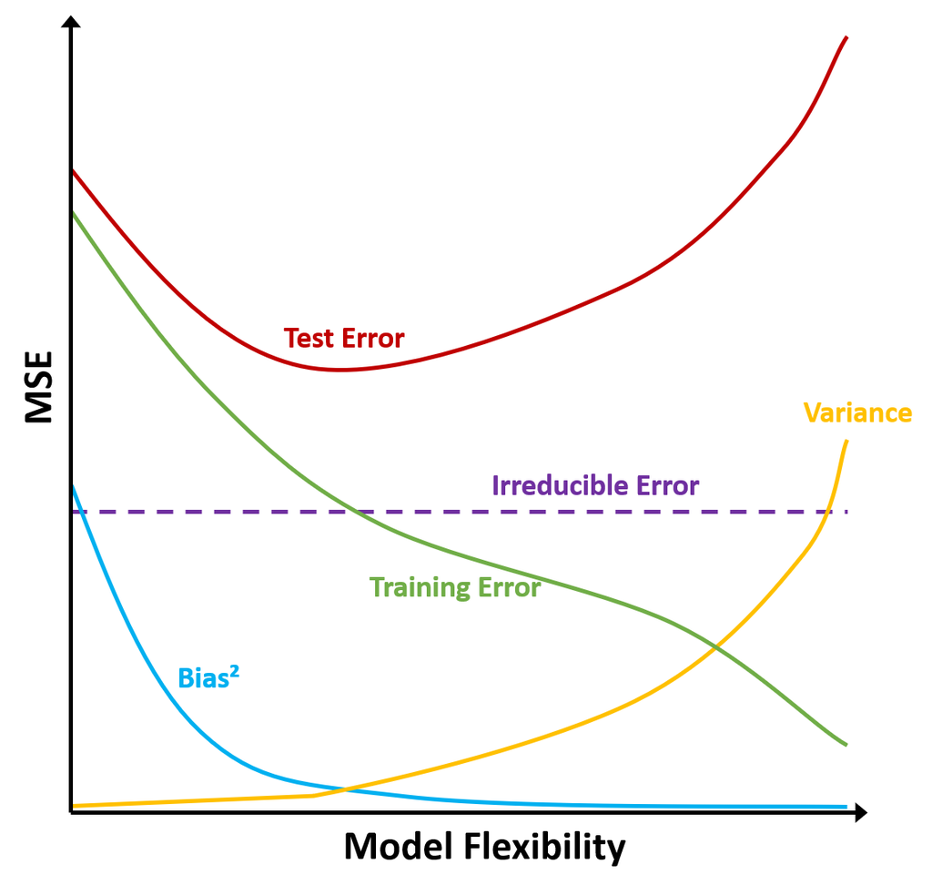

### (b)

Q: Explain why each of the five curves has the shape displayed in part (a).

A:

1. Bias(제곱 편향)
- 유연성이 증가할수록 편향이 감소한다. 편향은 실제 문제를 더 단순한 모델로 근사시킴으로 인해 발생되는 오차를 의미한다. 유연성이 증가하면 하나의 데이터 포인트에 대해서 영향을 받는 정도가 줄어들기 때문에 편향 역시 감소한다고 볼 수 있다.
2. Variance(분산)
- 유연성이 증가할수록 분산은 증가한다. 분산은 다른 training data를 사용하여 추정하는 경우 $\hat{f}$이 바뀌는 정도를 말한다. 이상적으로는 $\hat{f}$에 대한 추정이 훈련자료에 따라 크게 변동되지 않아야 한다. 하지만, 분산이 높으면 훈련 데이터의 변화가 적더라도 $\hat{f}$이 크게 변할 수 있다. 일반적으로 통계학습 방법의 유연성이 높을수록 분산이 높다. 유연한 곡선은 관측치들을 너무 잘 따라가기 때문에 분산이 높다고 할 수 있는데, 이 이유는 데이터 포인트 중 어느 하나를 변화시키면 이에 따른 $\hat{f}$가 크게 변할 수 있기 때문이다.
3. training Error(훈련 오차)
- 유연성이 증가할수록 훈련 오차는 감소한다.예를 들어 KNN에서 훈련오차율은 1/K로 나타낼 수 있는데, 1/K이 증가함에 따라 회귀 설정에서와 같이 훈련 오차율은 지속적으로 감소한다. 물론 유연한 방법은 일반적으로 분산이 높고 복잡한 관계를 완전히 학습할 수 있는 한편, 훈련 오차와 검정 오차의 분리가 나타나며 overfitting(과적합)문제는 발생할 수 있다.
4. Test Error(검정 오차)
- 유연성이 증가함에 따라 검정 오차는 처음에 감소하다가 유연성이 지나치게 커져 overfitting(과적합)이 일어날 때 다시 증가한다. 감소와 증가의 교차점은 bias-variance trade off 지점이다. 3)번의 훈련 오차와는 강한 상관관계는 없지만 KNN에서의 검정 오차와 훈련 오차는 동일한 1/K의 형태로 나타낼 수 있다.훈련 오차는 유연성이 증가함에 따라 지속적으로 감소하는 반면, 검정 오차는 U 모양을 띄며 감소하다가 다시 증가하는 형태를 가진다. 이 때, 최소지점은 대략 K=10일 때 가지게 된다.
5. Irreducible Error(베이즈 오차)
- 유연성 증가여부와 관계없이 베이즈 오차는 항상 일정하다. 베이즈 오차는 대략적으로 추정되는 system의 불확실성과 noise에 의해 생기는 오차를 의미한다. $\epsilon$은 $y$를 예측하는 데 사용되는 $X$에도 없는 측정되지 않은 변수를 포함할 수 있다. 즉,$\epsilon$은 $X$에서 설명이 불가능한 $y$의 측정할 수 없는 변동을 포함하기 때문에 모델의 유연성과는 관계없이 항상 일정한 값을 지닌다.

## ch2) 7. (풀이 : 최유나 / 기여 : 김나경)

### (a)

Q: Compute the Euclidean distance between each observation and the test point, Z=(X1,X2,X3)=(0,0,0).

A:

$d(a, b) = d(b, a) = \sqrt{\sum_{i = 1}^{p}(a_{i} - b_{i})^2}$

1. 관측치 1 : $\sqrt{3^2}$= **3**
2. 관측치 2 : $\sqrt{2^2}$= **2**
3. 관측치 3 : $\sqrt{1^2+3^2}$=$\sqrt{10}$= **3.1623**
4. 관측치 4 : $\sqrt{1^2+2^2}$=$\sqrt{5}$= **2.2361**
5. 관측치 5 : $\sqrt{(-1)^2+1^2}$=$\sqrt{2}$= **1.4142**
6. 관측치 6 : $\sqrt{1^2+1^2+1^2}$=$\sqrt{3}$= **1.7321**

### (b)

Q: What is our prediction with K = 1? Why?

A: 녹색이다. 다섯번째 관측치(1.4142)가 값에 가장 가깝기 때문이다.

### (c)

Q: What is our prediction with K = 3? Why?

A: 붉은색이다. 관측치와 가장 가까운 상위 세개는 관측치 2(2), 관측치 5(1.4142), 관측치 6(1.7321)이고, 관측치 5는 녹색이며 관측치 2, 관측치 6은 붉은 색이다. 따라서 녹색의 경우 추정 확률이 1/3이고, 붉은색의 경우 2/3이다. 따라서 KNN분류에서 K=3을 빨간색 등급에 속할 것이라 예측할 것이다.

### (d)

Q: If the Bayes decision boundary in this problem is highly nonlinear, then would we expect the best value for K to be large or small? Why?

A: small - 베이즈 결정경계가 아주 비선형적이면, 예상되는 최적의 $K$값은 더 작을 것이다. 작은 $K$는 더 유연할 것이고, KNN 경계의 변형이 쉬울 것이다. 반면, $K$값이 크다면 더 많은 데이터들을 고려하기 때문에 선형적 경계를 생성할 것이다.

## ch2) 8. (풀이 : 김나경 / 기여 : 최유나)

This exercise relates to the College data set, which can be found in the file College.csv. It contains a number of variables for 777 different universities and colleges in the US. The variables are

- Private: 공립/사립 지표
- Apps: 받은 응용 프로그램 수
- Accept: 수락한 신청자
- Enroll: 새로 등록한 학생 수
- Top10perc: 고등학교 수업의 상위 10%의 신입생
- Top25perc: 고등학교 수업의 상위 25%의 신입생
- F.Undergrad: 정규 학부생 수
- P.Undergrad: part-time 학부생 수
- Outstate: 주 외 교육비
- Room.Board: 객실 및 보드 비용
- Books: 도서 예상 비용
- Personal: 개인 지출 추정치
- PhD: 박사학위 소지 교수 비율
- Terminal: terminal 학위가 있는 교수진의 비율
- S.F.Ratio: 학생/학력비
- perc.alumni: 기부하는 동문 비율
- Expend: 학생당 교육비
- Grad.Rate: 졸업률

### (a)

Use the read.csv() function to read the data into R. Call the loaded data college. Make sure that you have the directory set to the correct location for the data.

```r
# csv파일 불러오기
college <- read.csv("./data/College.csv", header=TRUE)
str(college) # check, 첫 변수가 college name
```

```
## 'data.frame':    777 obs. of  19 variables:
##  $ X          : chr  "Abilene Christian University" "Adelphi University" "Adrian College" "Agnes Scott College" ...
##  $ Private    : chr  "Yes" "Yes" "Yes" "Yes" ...
##  $ Apps       : int  1660 2186 1428 417 193 587 353 1899 1038 582 ...
##  $ Accept     : int  1232 1924 1097 349 146 479 340 1720 839 498 ...
##  $ Enroll     : int  721 512 336 137 55 158 103 489 227 172 ...
##  $ Top10perc  : int  23 16 22 60 16 38 17 37 30 21 ...
##  $ Top25perc  : int  52 29 50 89 44 62 45 68 63 44 ...
##  $ F.Undergrad: int  2885 2683 1036 510 249 678 416 1594 973 799 ...
##  $ P.Undergrad: int  537 1227 99 63 869 41 230 32 306 78 ...
##  $ Outstate   : int  7440 12280 11250 12960 7560 13500 13290 13868 15595 10468 ...
##  $ Room.Board : int  3300 6450 3750 5450 4120 3335 5720 4826 4400 3380 ...
##  $ Books      : int  450 750 400 450 800 500 500 450 300 660 ...
##  $ Personal   : int  2200 1500 1165 875 1500 675 1500 850 500 1800 ...
##  $ PhD        : int  70 29 53 92 76 67 90 89 79 40 ...
##  $ Terminal   : int  78 30 66 97 72 73 93 100 84 41 ...
##  $ S.F.Ratio  : num  18.1 12.2 12.9 7.7 11.9 9.4 11.5 13.7 11.3 11.5 ...
##  $ perc.alumni: int  12 16 30 37 2 11 26 37 23 15 ...
##  $ Expend     : int  7041 10527 8735 19016 10922 9727 8861 11487 11644 8991 ...
##  $ Grad.Rate  : int  60 56 54 59 15 55 63 73 80 52 ...
```

### (b)

Look at the data using the fix() function. You should notice that the first column is just the name of each university. We don’t really want R to treat this as data. However, it may be handy to have these names for later. - fix() 는 Rstudio에서는 지원하지 않는 함수입니다.

```r
#대학 이름을 인덱스에 추가
#첫 번째 열을 삭제
rownames(college) <- college[,1]
college[,1] <- NULL

head(college)
```

```
##                              Private Apps Accept Enroll Top10perc Top25perc
## Abilene Christian University     Yes 1660   1232    721        23        52
## Adelphi University               Yes 2186   1924    512        16        29
## Adrian College                   Yes 1428   1097    336        22        50
## Agnes Scott College              Yes  417    349    137        60        89
## Alaska Pacific University        Yes  193    146     55        16        44
## Albertson College                Yes  587    479    158        38        62
##                              F.Undergrad P.Undergrad Outstate Room.Board Books
## Abilene Christian University        2885         537     7440       3300   450
## Adelphi University                  2683        1227    12280       6450   750
## Adrian College                      1036          99    11250       3750   400
## Agnes Scott College                  510          63    12960       5450   450
## Alaska Pacific University            249         869     7560       4120   800
## Albertson College                    678          41    13500       3335   500
##                              Personal PhD Terminal S.F.Ratio perc.alumni Expend
## Abilene Christian University     2200  70       78      18.1          12   7041
## Adelphi University               1500  29       30      12.2          16  10527
## Adrian College                   1165  53       66      12.9          30   8735
## Agnes Scott College               875  92       97       7.7          37  19016
## Alaska Pacific University        1500  76       72      11.9           2  10922
## Albertson College                 675  67       73       9.4          11   9727
##                              Grad.Rate
## Abilene Christian University        60
## Adelphi University                  56
## Adrian College                      54
## Agnes Scott College                 59
## Alaska Pacific University           15
## Albertson College                   55
```